# Fall 2020 - Math 421 - Midterm

## II. Data Visualization

Continue with the data from part I.

1. Provides at least 10 meaningful plots. Comments on the plots. All plots should have title, caption, appropriate labels on x and y-axis

Avg. Length of Stay by Payer

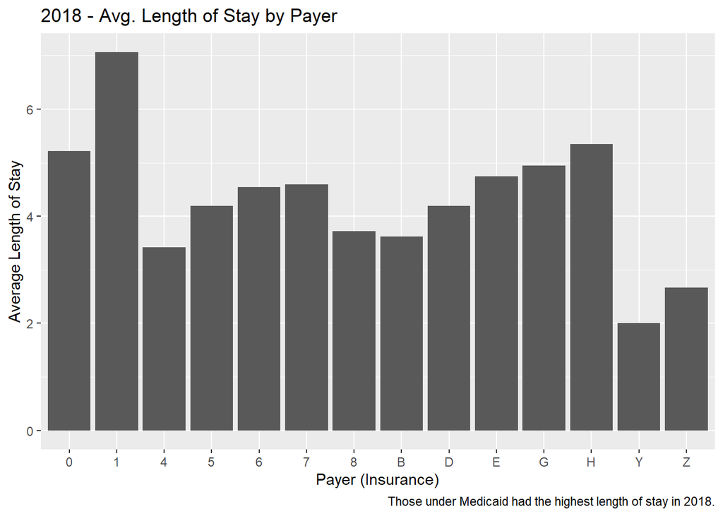

```r
df %>% group_by(payer) %>% summarise(avg_los=mean(los)) %>% arrange(desc(avg_los,.by_group=TRUE)) %>%  ggplot()+geom_col(mapping=aes(x=payer, y=avg_los))+
    labs(
        x= 'Payer (Insurance)',
        y ='Average Length of Stay',
        title = '2018 - Avg. Length of Stay by Payer',
        caption = 'Those under Medicaid had the highest length of stay in 2018.')
```

Total Charges by Length of Stay and Age

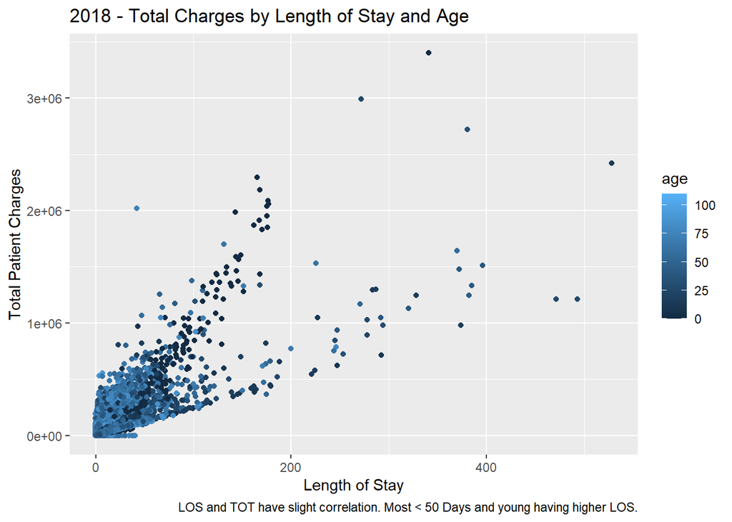

```r
df %>% ggplot()+geom_point(mapping = aes(x = los, y = tot,color = age),position='jitter')+
    labs(
        x= 'Length of Stay',
        y ='Total Patient Charges',
        title = '2018 - Total Charges by Length of Stay and Age',
        caption = 'LOS and TOT have slight correlation. Most < 50 Days and young having higher LOS.')
```

Length of Stay by Age

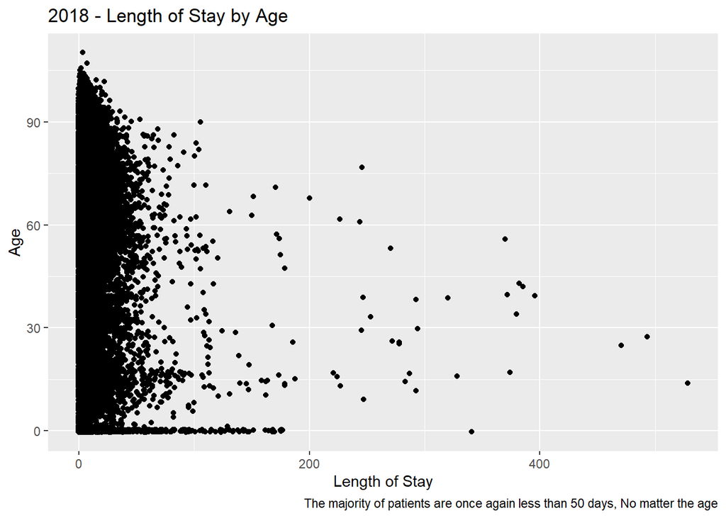

```r
df %>% ggplot()+geom_point(mapping = aes(x = los, y = age),position='jitter')+
    labs(
        x= 'Length of Stay',
        y ='Age',
        title = '2018 - Length of Stay by Age',
        caption = 'The majority of patients are once again less than 50 days, No matter the age')
```

Boxplot Age by Provider (Hospital)

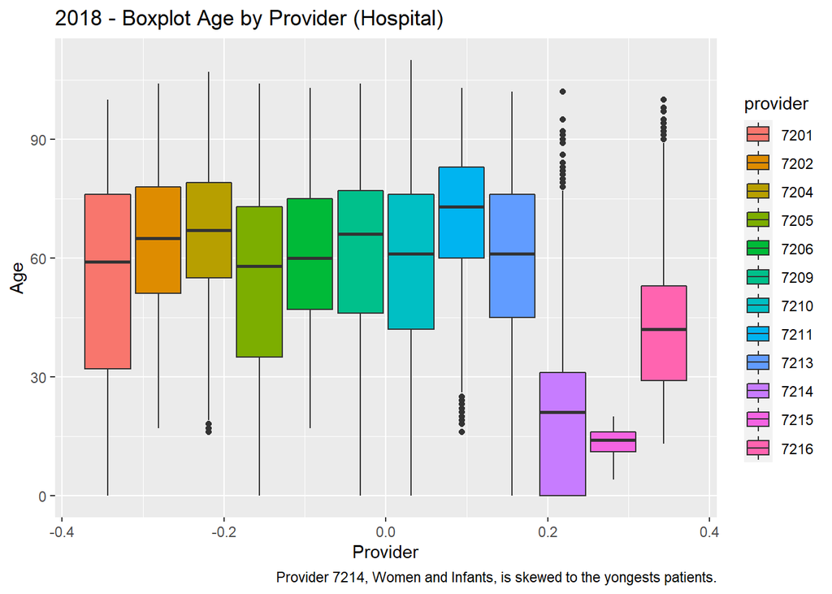

```r
df %>% ggplot()+geom_boxplot(mapping = aes(y = age,fill=provider))+
    labs(
        x= 'Provider',
        y ='Age',
        title = '2018 - Boxplot Age by Provider (Hospital)',
        caption = 'Provider 7214, Women and Infants, is skewed to the yongests patients.')
```

Number of Cases by Patient Origin

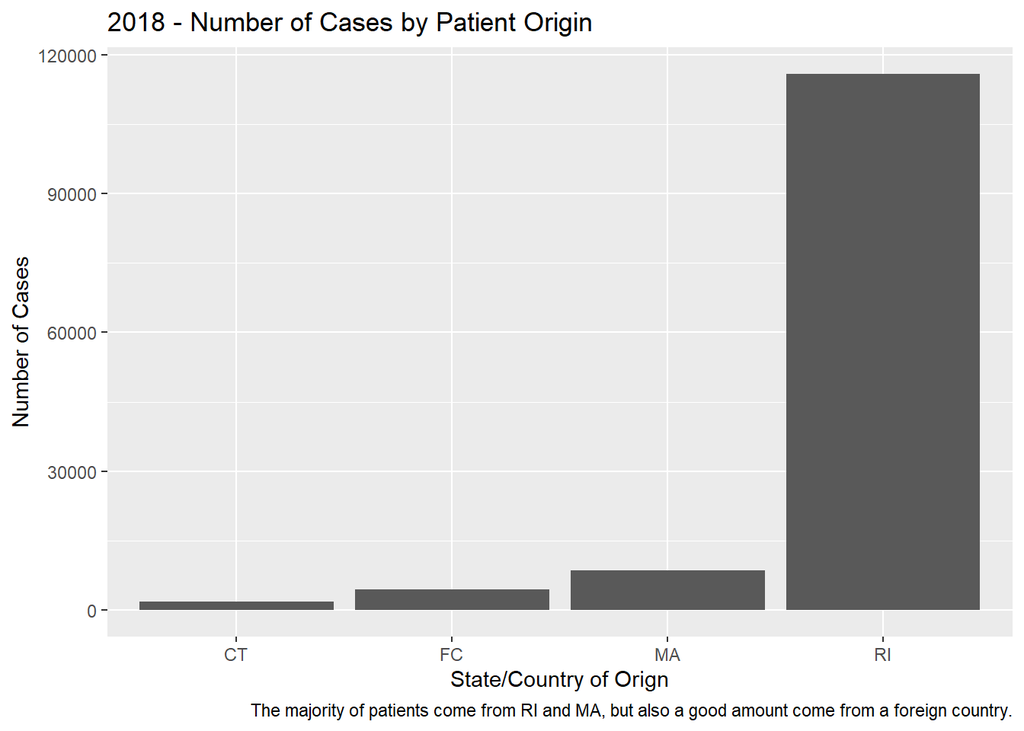

```r
df %>% filter(pt_state %in% names(sort(table(df$pt_state),decreasing=TRUE)[1:4])) %>% ggplot()+ geom_bar(mapping=aes(x=pt_state))+
    labs(
        x= 'State/Country of Orign',
        y ='Number of Cases',
        title = '2018 - Number of Cases by Patient Origin',
        caption = 'The majority of patients come from RI and MA, but also a good amount come from a foreign country.')
```

Number of Admissions by Month

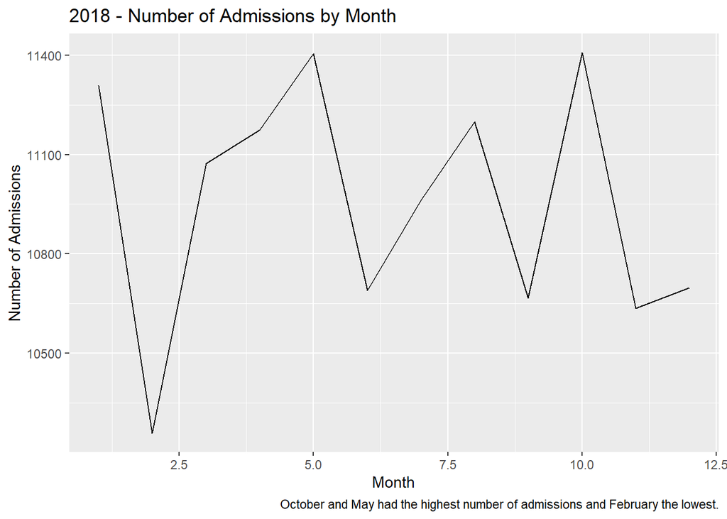

```r
df %>% group_by(moa) %>% summarise(count=n()) %>%  ggplot()+geom_line(mapping = aes(x = moa, y = count))+
    labs(
        x= 'Month',
        y ='Number of Admissions',
        title = '2018 - Number of Admissions by Month',
        caption = 'October and May had the highest number of admissions and February the lowest.')
```

Number of Newborn Cases by Month

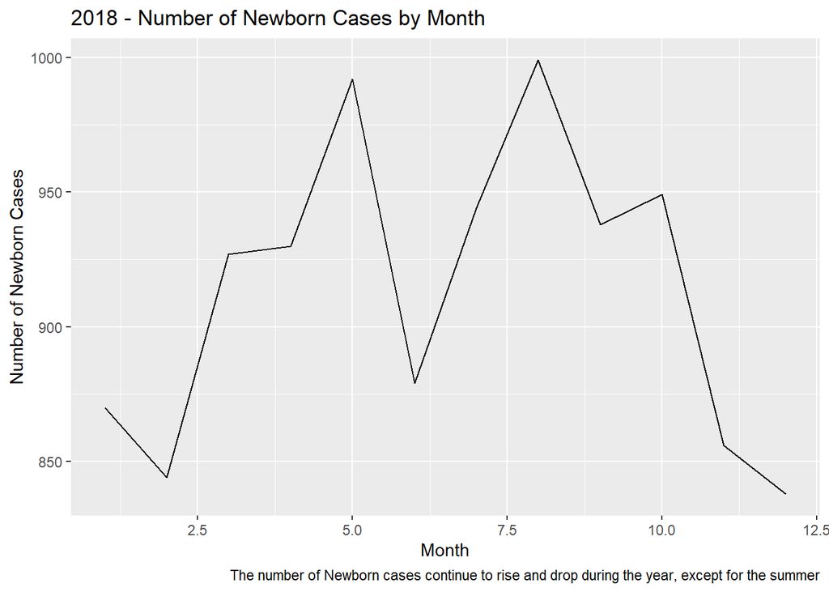

```r
df %>% group_by(moa) %>% filter(admtype == 4) %>% summarise(count=n()) %>%  ggplot()+geom_line(mapping = aes(x = moa, y = count))+
    labs(
        x= 'Month',
        y ='Number of Newborn Cases',
        title = '2018 - Number of Newborn Cases by Month',
        caption = 'The number of Newborn cases continue to rise and drop during the year, except for the summer')
```

Admission Type by Proportion of Gender

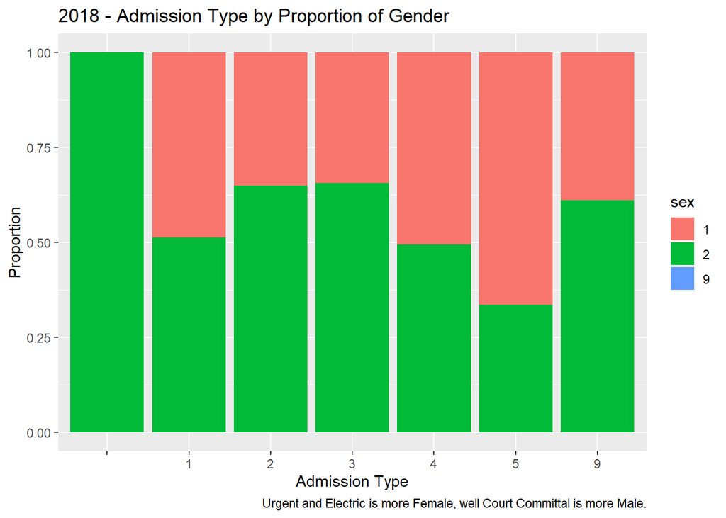

```r
df %>% ggplot()+geom_bar(mapping = aes(x = admtype, fill = sex),position = 'fill')+
      labs(
        x= 'Admission Type',
        y ='Proportion',
        title = '2018 - Admission Type by Proportion of Gender',
        caption = 'Urgent and Electric is more Female, well Court Committal is more Male.')
```

Number of Cases by Hospital & Admission Type

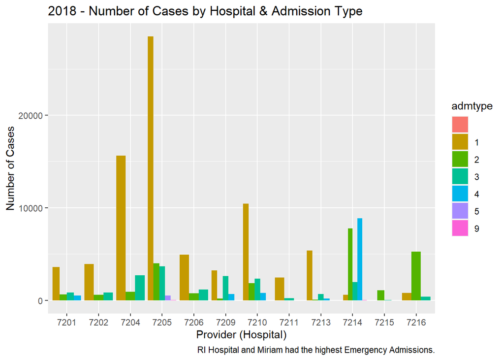

```r
df %>% ggplot()+
    geom_bar(mapping=aes(x=provider, fill=admtype), position='dodge')+
    labs(
        x= 'Provider (Hospital)',
        y ='Number of Cases',
        title = '2018 - Number of Cases by Hospital & Admission Type',
        caption = 'RI Hospital and Miriam had the highest Emergency Admissions.')
```

2. Make an animation

Number of Out-of-state Admissions by Month

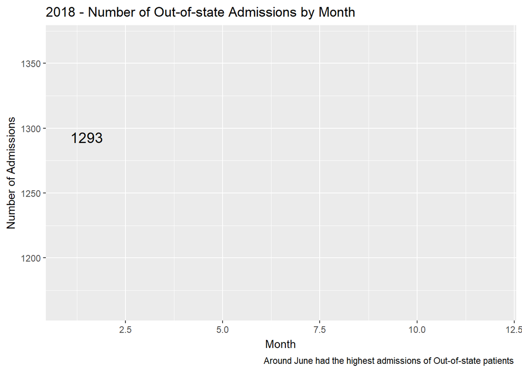

```r
df %>% group_by(moa) %>% filter(pt_state != 'RI') %>% summarise(count=n()) %>% ggplot(aes(moa,count))+geom_line()+geom_text(aes(label = count), hjust = -.1, size=5) +
transition_reveal(moa)+labs(
        x= 'Month',
        y ='Number of Admissions',
        title = '2018 - Number of Out-of-state Admissions by Month ',
        caption = 'Around June had the highest admissions of Out-of-state patients ')
```

## III. Predictive Models

Continue with the data from part I. Use the follows as the target and input variables:

*Target Variable*: Create the target variable taking value of

- `low cost` if the total charge of a patient (`tot`) is smaller than the median of the total charge, and
- `high cost` otherwise.

```r
df2 <- df

df2$target <- case_when(
    df2$tot < median(df2$tot) ~ 'low_cost',
    TRUE ~ 'high_cost'
)
```

*Input Variables*:

- “age”,“sex”,“raceethn”,“provider”,“moa”,“mod”,“admtype”,“campus”, “er_mode”, ‘los’

```r
df2 <- df2[,c("age","sex","raceethn","provider","moa","mod","admtype","campus", "er_mode", "los", "target")]

df2$target <- factor(df2$target)
df2$sex <- factor(df2$sex)
df2$raceethn <- factor(df2$raceethn)
df2$provider <- factor(df2$provider)
df2$moa <- factor(df2$moa)
df2$mod <- factor(df2$mod)
df2$admtype <- factor(df2$admtype)
df2$campus <- factor(df2$campus)
df2$er_mode <- factor(df2$er_mode)
```

```r
set.seed(2020)

splitIndex <- createDataPartition(df2$target, p = .90, list = FALSE)
df_train <- df2[ splitIndex,]
df_test <- df2[-splitIndex,]
```

2. Train a decision tree using `rpart`. Plot the decision tree. Plot the variable importance ranked by the tree.

```r
decision_tree_model <- rpart(target ~ ., data = df_train, control = rpart.control(maxdepth = 3))
decision_tree_model$variable.importance
```

```
##        los    admtype   provider        age     campus    er_mode   raceethn
## 15929.8519  4235.9023  3539.6843  2010.8394   803.9562   468.8701   168.6954
```

Variable Importance Bar Chart

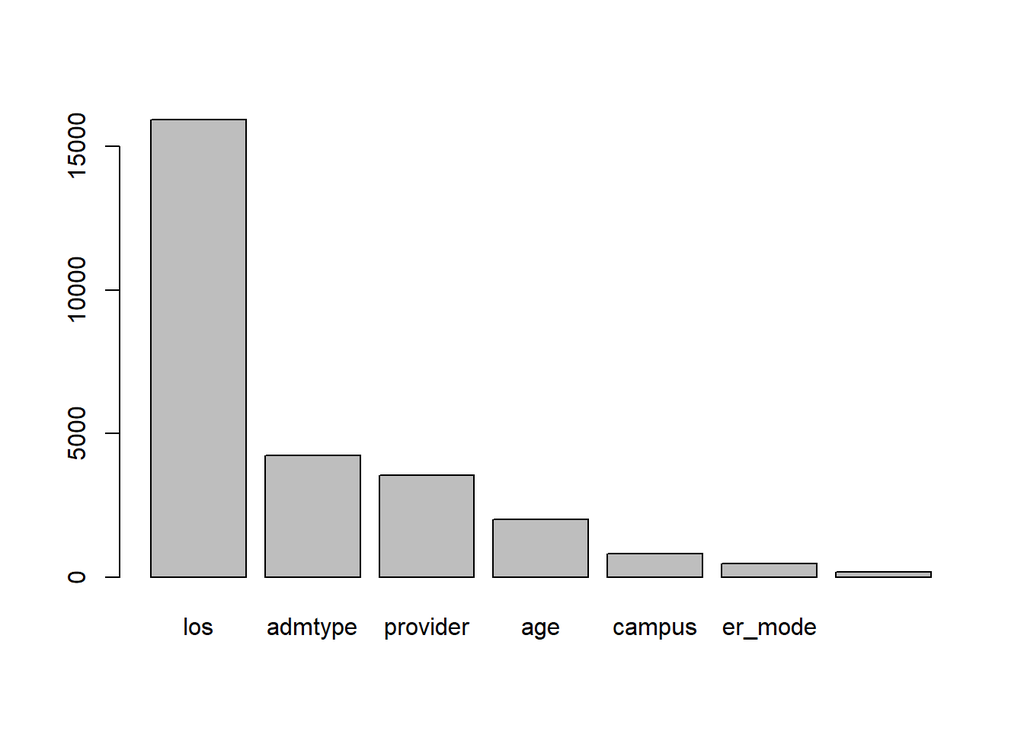

```r
barplot(decision_tree_model$variable.importance)
```

Decision Tree Plot

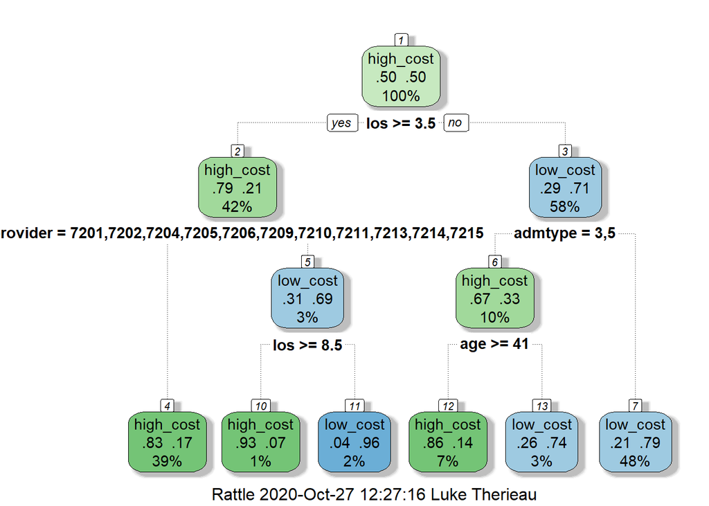

```r
fancyRpartPlot(decision_tree_model)
```

3. Using caret for this question. Set `Training Control` to be: Use Cross-Validation of 5 folds across all models. Train & tune at least 3 different models (i.e. three different values for `method=` in the train function of caret). Plot the hyper-parameter tuning plots for each model.

approach1

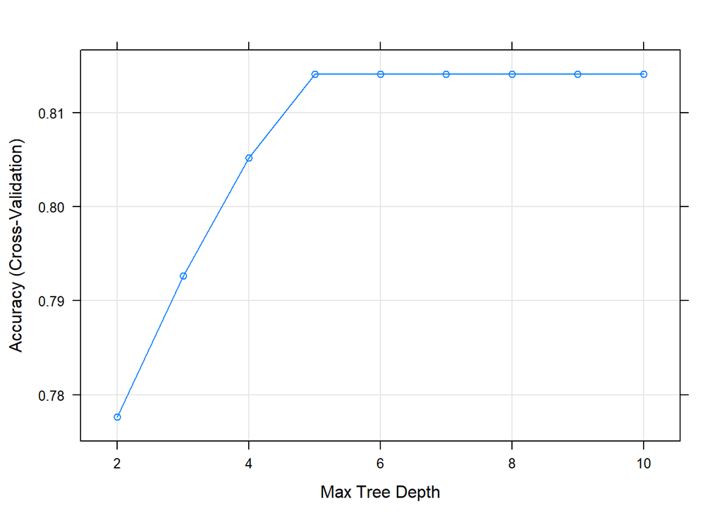

```r
tuneGrid = expand.grid(maxdepth = 2:10)
trControl = trainControl(method = "cv",
                         number = 5)
approach1 <- train(target~., data=df_train, method = "rpart2", trControl = trControl,tuneGrid = tuneGrid)
plot(approach1)
```

approach2

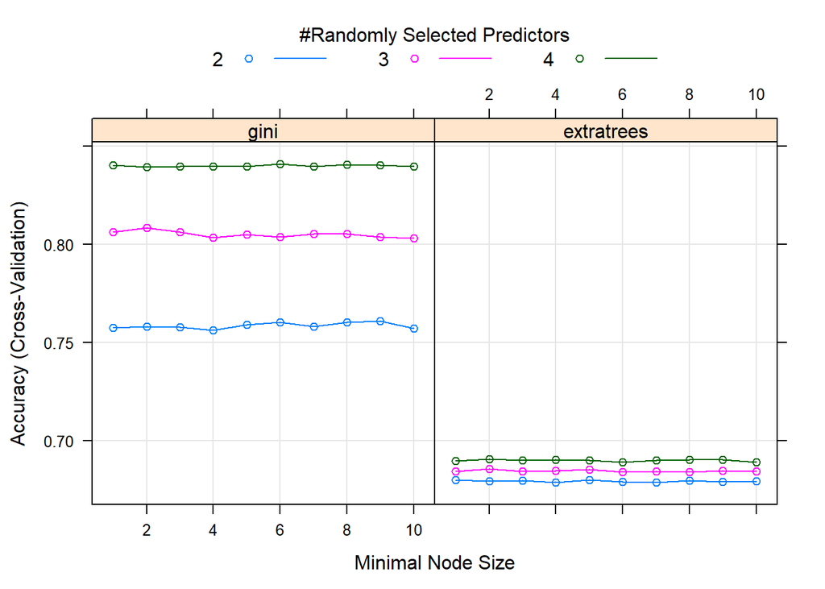

```r
trControl = trainControl(method = "cv",number = 5)
tuneGrid = expand.grid(mtry = 2:4,splitrule = c('gini','extratrees'),min.node.size = c(1:10))

approach2 <- train(target~., data=df_train, method = "ranger", trControl = trControl, tuneGrid = tuneGrid)
plot(approach2)
```

approach3

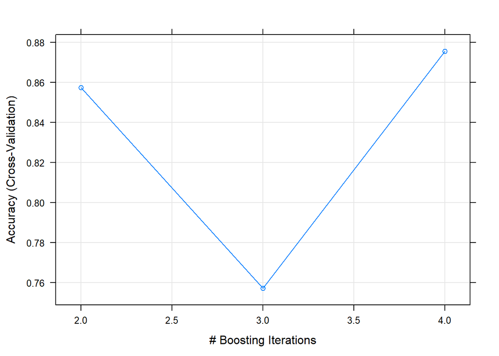

```r
trControl = trainControl(method = "cv",number = 5)

tuneGrid = expand.grid(nIter = 2:4)

approach3 <- train(target~., data=df_train, method = "LogitBoost", trControl = trControl, tuneGrid = tuneGrid)
plot(approach3)
```

4. Plot the comparison of the models in 2.

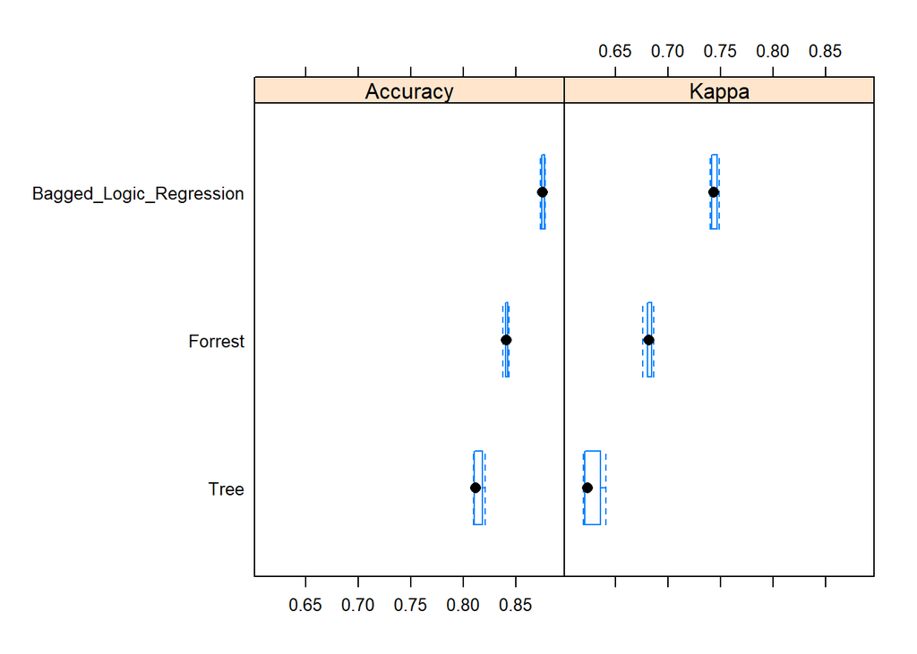

```r
results <- resamples(list(Tree = approach1,Forrest = approach2,Bagged_Logic_Regression = approach3))
bwplot(results)
```

5. What is your final selection for the model? Test the accuracy of your final model on the test data.

```r
model <- approach3
pred <- predict(model, df_test)
cm <- confusionMatrix(data = pred, reference = df_test$target, positive = 'low_cost')
cm$overall[1]
```

```
##  Accuracy
## 0.8796983
```

6. Create another `target` variable (binary), decide the input variables and redo 1 to 5.